# Part I - (201902 Fordgobike Trip Data Exploration)

## Introduction

This dataset includes information about individual rides made in a bike-sharing system covering the greater San Francisco Bay area.

## Preliminary Wrangling

```python
# import all packages and set plots to be embedded inline
import numpy as np
import pandas as pd
import matplotlib.pyplot as plt
import seaborn as sb
import datetime as dt

%matplotlib inline
```

```python
gobike = pd.read_csv('201902-fordgobike-tripdata.csv')
gobike.head()
```

|  | duration_sec | start_time | end_time | start_station_id | start_station_name | start_station_latitude | start_station_longitude | end_station_id | end_station_name | end_station_latitude | end_station_longitude | bike_id | user_type | member_birth_year | member_gender | bike_share_for_all_trip |
| --- | --- | --- | --- | --- | --- | --- | --- | --- | --- | --- | --- | --- | --- | --- | --- | --- |
| 0 | 52185 | 2019-02-28 17:32:10.1450 | 2019-03-01 08:01:55.9750 | 21.0 | Montgomery St BART Station (Market St at 2nd St) | 37.789625 | -122.400811 | 13.0 | Commercial St at Montgomery St | 37.794231 | -122.402923 | 4902 | Customer | 1984.0 | Male | No |
| 1 | 42521 | 2019-02-28 18:53:21.7890 | 2019-03-01 06:42:03.0560 | 23.0 | The Embarcadero at Steuart St | 37.791464 | -122.391034 | 81.0 | Berry St at 4th St | 37.775880 | -122.393170 | 2535 | Customer | NaN | NaN | No |
| 2 | 61854 | 2019-02-28 12:13:13.2180 | 2019-03-01 05:24:08.1460 | 86.0 | Market St at Dolores St | 37.769305 | -122.426826 | 3.0 | Powell St BART Station (Market St at 4th St) | 37.786375 | -122.404904 | 5905 | Customer | 1972.0 | Male | No |
| 3 | 36490 | 2019-02-28 17:54:26.0100 | 2019-03-01 04:02:36.8420 | 375.0 | Grove St at Masonic Ave | 37.774836 | -122.446546 | 70.0 | Central Ave at Fell St | 37.773311 | -122.444293 | 6638 | Subscriber | 1989.0 | Other | No |
| 4 | 1585 | 2019-02-28 23:54:18.5490 | 2019-03-01 00:20:44.0740 | 7.0 | Frank H Ogawa Plaza | 37.804562 | -122.271738 | 222.0 | 10th Ave at E 15th St | 37.792714 | -122.248780 | 4898 | Subscriber | 1974.0 | Male | Yes |

```python
gobike.info()
```

```
<class 'pandas.core.frame.DataFrame'>
RangeIndex: 183412 entries, 0 to 183411
Data columns (total 16 columns):
duration_sec               183412 non-null int64
start_time                 183412 non-null object
end_time                   183412 non-null object
start_station_id           183215 non-null float64
start_station_name         183215 non-null object
start_station_latitude     183412 non-null float64
start_station_longitude    183412 non-null float64
end_station_id             183215 non-null float64
end_station_name           183215 non-null object
end_station_latitude       183412 non-null float64
end_station_longitude      183412 non-null float64
bike_id                    183412 non-null int64
user_type                  183412 non-null object
member_birth_year          175147 non-null float64
member_gender              175147 non-null object
bike_share_for_all_trip    183412 non-null object
dtypes: float64(7), int64(2), object(7)
memory usage: 22.4+ MB
```

```python
#Checking for null values in the dataset
gobike.isnull().sum()
```

```
duration_sec                  0
start_time                    0
end_time                      0
start_station_id            197
start_station_name          197
start_station_latitude        0
start_station_longitude       0
end_station_id              197
end_station_name            197
end_station_latitude          0
end_station_longitude         0
bike_id                       0
user_type                     0
member_birth_year          8265
member_gender              8265
bike_share_for_all_trip       0
dtype: int64
```

```python
#making a copy of the dataset before cleaning
gobike_clean = gobike.copy()
```

```python
#checking for duplicates values
gobike_clean.duplicated().sum()
```

```
0
```

```python
#Dropping null values in the dataset using the member_birth_year and state_station_id columns
gobike_clean.dropna(subset=['member_birth_year', 'start_station_id'], inplace=True)
```

```python
#Checking the result of the cleaning
gobike_clean.isnull().sum()
```

```
duration_sec               0
start_time                 0
end_time                   0
start_station_id           0
start_station_name         0
start_station_latitude     0
start_station_longitude    0
end_station_id             0
end_station_name           0
end_station_latitude       0
end_station_longitude      0
bike_id                    0
user_type                  0
member_birth_year          0
member_gender              0
bike_share_for_all_trip    0
dtype: int64
```

#### Cleaning the Null Values

The below null values were discovered in the dataset and they has to be cleaned before data exploration to get accurate visualization. start_station_id: 197, start_station_name: 197, end_station_id: 197, end_station_name: 197, member_birth_year: 8265, member_gender: 8265, The date was clean using the start_station_id and member_birth_year column since start_station_id, start_station_name, end_station_id and end_station_name has common null values; member_birth_year and member_gender also have common null values. After cleaning the null values the dataset dropped from 183412 rows to 174952 rows

```python
#Dealing with the wrong Data types
gobike_clean.bike_share_for_all_trip = gobike_clean.bike_share_for_all_trip.astype('category')
gobike_clean.start_time = pd.to_datetime(gobike_clean.start_time)
gobike_clean.end_time = pd.to_datetime(gobike_clean.end_time)
gobike_clean.member_birth_year = gobike_clean.member_birth_year.astype(int)
gobike_clean.info()
```

```
<class 'pandas.core.frame.DataFrame'>
Int64Index: 174952 entries, 0 to 183411
Data columns (total 16 columns):
duration_sec               174952 non-null int64
start_time                 174952 non-null datetime64[ns]
end_time                   174952 non-null datetime64[ns]
start_station_id           174952 non-null float64
start_station_name         174952 non-null object
start_station_latitude     174952 non-null float64
start_station_longitude    174952 non-null float64
end_station_id             174952 non-null float64
end_station_name           174952 non-null object
end_station_latitude       174952 non-null float64
end_station_longitude      174952 non-null float64
bike_id                    174952 non-null int64
user_type                  174952 non-null object
member_birth_year          174952 non-null int64
member_gender              174952 non-null object
bike_share_for_all_trip    174952 non-null category
dtypes: category(1), datetime64[ns](2), float64(6), int64(3), object(4)
memory usage: 21.5+ MB
```

#### Dealing with Erroneous Datatype

The below erroneous datatype were discovered and corrected

bike_share_for_all_trip initially has object dataype and was converted to category datatype

start_time initially has object dataype and was converted to Datetime datatype

end_time initially has object dataype and was converted to datetime datetype

```python
#Extracting the month of the year, days of the week and time of the day from start_time and end_time
gobike_clean['start_month']=gobike_clean.start_time.dt.month_name()
gobike_clean['end_month']=gobike_clean.end_time.dt.month_name()
gobike_clean['start_day'] = gobike_clean.start_time.dt.weekday_name
gobike_clean['end_day']= gobike_clean.end_time.dt.weekday_name
gobike_clean['start_hour'] = gobike_clean.start_time.dt.hour
gobike_clean['end_hour']= gobike_clean.end_time.dt.hour
```

```python
#creating Age column using the member birth year column
gobike_clean['age']= 2019 - gobike_clean.member_birth_year
gobike_clean.head()
```

|  | duration_sec | start_time | end_time | start_station_id | start_station_name | start_station_latitude | start_station_longitude | end_station_id | end_station_name | end_station_latitude | ... | member_birth_year | member_gender | bike_share_for_all_trip | start_month | end_month | start_day | end_day | start_hour | end_hour | age |
| --- | --- | --- | --- | --- | --- | --- | --- | --- | --- | --- | --- | --- | --- | --- | --- | --- | --- | --- | --- | --- | --- |
| 0 | 52185 | 2019-02-28 17:32:10.145 | 2019-03-01 08:01:55.975 | 21.0 | Montgomery St BART Station (Market St at 2nd St) | 37.789625 | -122.400811 | 13.0 | Commercial St at Montgomery St | 37.794231 | ... | 1984 | Male | No | February | March | Thursday | Friday | 17 | 8 | 35 |
| 2 | 61854 | 2019-02-28 12:13:13.218 | 2019-03-01 05:24:08.146 | 86.0 | Market St at Dolores St | 37.769305 | -122.426826 | 3.0 | Powell St BART Station (Market St at 4th St) | 37.786375 | ... | 1972 | Male | No | February | March | Thursday | Friday | 12 | 5 | 47 |
| 3 | 36490 | 2019-02-28 17:54:26.010 | 2019-03-01 04:02:36.842 | 375.0 | Grove St at Masonic Ave | 37.774836 | -122.446546 | 70.0 | Central Ave at Fell St | 37.773311 | ... | 1989 | Other | No | February | March | Thursday | Friday | 17 | 4 | 30 |
| 4 | 1585 | 2019-02-28 23:54:18.549 | 2019-03-01 00:20:44.074 | 7.0 | Frank H Ogawa Plaza | 37.804562 | -122.271738 | 222.0 | 10th Ave at E 15th St | 37.792714 | ... | 1974 | Male | Yes | February | March | Thursday | Friday | 23 | 0 | 45 |
| 5 | 1793 | 2019-02-28 23:49:58.632 | 2019-03-01 00:19:51.760 | 93.0 | 4th St at Mission Bay Blvd S | 37.770407 | -122.391198 | 323.0 | Broadway at Kearny | 37.798014 | ... | 1959 | Male | No | February | March | Thursday | Friday | 23 | 0 | 60 |

5 rows × 23 columns

#### The Data Extraction

The Months of the year, days of the week and hours of the day were extracted into separate columns from the start time and end time columns respectively for more insight into the dataset.

```python
gobike_clean.to_csv('201902-fordgobike-tripdata_master.csv', index=False)
```

### What is/are the main feature(s) of interest in your dataset?

The main features of interest are as follows: Duration, User Type and Bike Share for all Trip

### What features in the dataset do you think will help support your investigation into your feature(s) of interest?

The following features will support my investigation into the my features of interest: Member Gender, Start Time, End Time, Start Station Name, End Station Name, start_day, end_day, Start_hour, end_hour, age.

## Univariate Exploration

```python
#importing the cleaned dataset to a data frame
gobike_trip = pd.read_csv('201902-fordgobike-tripdata_master.csv')
print(gobike_trip.shape)
gobike_trip.head()
```

```
(174952, 23)
```

|  | duration_sec | start_time | end_time | start_station_id | start_station_name | start_station_latitude | start_station_longitude | end_station_id | end_station_name | end_station_latitude | ... | member_birth_year | member_gender | bike_share_for_all_trip | start_month | end_month | start_day | end_day | start_hour | end_hour | age |
| --- | --- | --- | --- | --- | --- | --- | --- | --- | --- | --- | --- | --- | --- | --- | --- | --- | --- | --- | --- | --- | --- |
| 0 | 52185 | 2019-02-28 17:32:10.145 | 2019-03-01 08:01:55.975 | 21.0 | Montgomery St BART Station (Market St at 2nd St) | 37.789625 | -122.400811 | 13.0 | Commercial St at Montgomery St | 37.794231 | ... | 1984 | Male | No | February | March | Thursday | Friday | 17 | 8 | 35 |
| 1 | 61854 | 2019-02-28 12:13:13.218 | 2019-03-01 05:24:08.146 | 86.0 | Market St at Dolores St | 37.769305 | -122.426826 | 3.0 | Powell St BART Station (Market St at 4th St) | 37.786375 | ... | 1972 | Male | No | February | March | Thursday | Friday | 12 | 5 | 47 |
| 2 | 36490 | 2019-02-28 17:54:26.010 | 2019-03-01 04:02:36.842 | 375.0 | Grove St at Masonic Ave | 37.774836 | -122.446546 | 70.0 | Central Ave at Fell St | 37.773311 | ... | 1989 | Other | No | February | March | Thursday | Friday | 17 | 4 | 30 |
| 3 | 1585 | 2019-02-28 23:54:18.549 | 2019-03-01 00:20:44.074 | 7.0 | Frank H Ogawa Plaza | 37.804562 | -122.271738 | 222.0 | 10th Ave at E 15th St | 37.792714 | ... | 1974 | Male | Yes | February | March | Thursday | Friday | 23 | 0 | 45 |
| 4 | 1793 | 2019-02-28 23:49:58.632 | 2019-03-01 00:19:51.760 | 93.0 | 4th St at Mission Bay Blvd S | 37.770407 | -122.391198 | 323.0 | Broadway at Kearny | 37.798014 | ... | 1959 | Male | No | February | March | Thursday | Friday | 23 | 0 | 60 |

5 rows × 23 columns

```python
#Displaying the statistical value of the datset
gobike_trip.describe()
```

|  | duration_sec | start_station_id | start_station_latitude | start_station_longitude | end_station_id | end_station_latitude | end_station_longitude | bike_id | member_birth_year | start_hour | end_hour | age |
| --- | --- | --- | --- | --- | --- | --- | --- | --- | --- | --- | --- | --- |
| count | 174952.000000 | 174952.000000 | 174952.000000 | 174952.000000 | 174952.000000 | 174952.000000 | 174952.000000 | 174952.000000 | 174952.000000 | 174952.000000 | 174952.000000 | 174952.000000 |
| mean | 704.002744 | 139.002126 | 37.771220 | -122.351760 | 136.604486 | 37.771414 | -122.351335 | 4482.587555 | 1984.803135 | 13.456165 | 13.609533 | 34.196865 |
| std | 1642.204905 | 111.648819 | 0.100391 | 0.117732 | 111.335635 | 0.100295 | 0.117294 | 1659.195937 | 10.118731 | 4.734282 | 4.748029 | 10.118731 |
| min | 61.000000 | 3.000000 | 37.317298 | -122.453704 | 3.000000 | 37.317298 | -122.453704 | 11.000000 | 1878.000000 | 0.000000 | 0.000000 | 18.000000 |
| 25% | 323.000000 | 47.000000 | 37.770407 | -122.411901 | 44.000000 | 37.770407 | -122.411647 | 3799.000000 | 1980.000000 | 9.000000 | 9.000000 | 27.000000 |
| 50% | 510.000000 | 104.000000 | 37.780760 | -122.398279 | 101.000000 | 37.781010 | -122.397437 | 4960.000000 | 1987.000000 | 14.000000 | 14.000000 | 32.000000 |
| 75% | 789.000000 | 239.000000 | 37.797320 | -122.283093 | 238.000000 | 37.797673 | -122.286533 | 5505.000000 | 1992.000000 | 17.000000 | 18.000000 | 39.000000 |
| max | 84548.000000 | 398.000000 | 37.880222 | -121.874119 | 398.000000 | 37.880222 | -121.874119 | 6645.000000 | 2001.000000 | 23.000000 | 23.000000 | 141.000000 |

[output not shown]

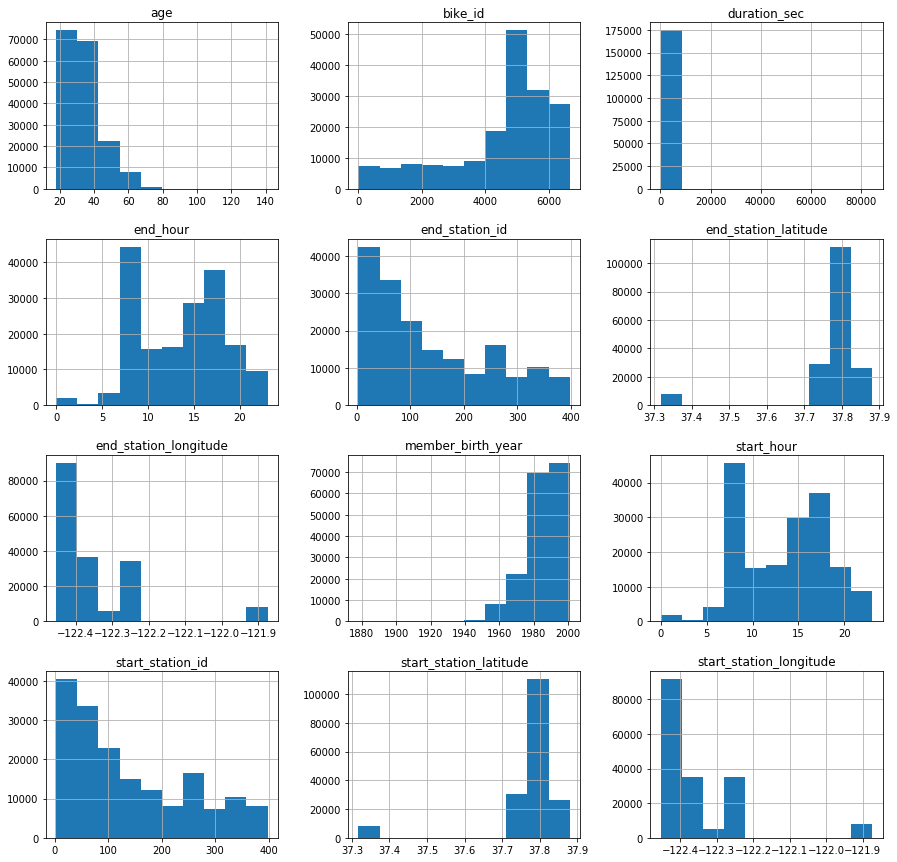

```python
# Displaying the number columns values of the dataset wit a histogram
gobike_trip.hist(figsize = (15,15))
```

```python
# creating a fuction that will be used for ploting chart

def plot_chart(df,x,y,t,k):
    df.plot(y=y, x=x, title=t, rot=90, kind=k, figsize=(10,10))
    plt.xlabel(x, fontsize=12)
    plt.ylabel(y, fontsize=12)
    return plt.show()

def bar_chart(df,x,y,h,t):
    plt.figure(figsize = [10, 10])
    sb.countplot(data=df, x=x, hue=h).set(xlabel=x, ylabel=y, title=t)
    plt.xlabel(x, fontsize=12)
    plt.ylabel(y, fontsize=12)
    plt.title(t, fontsize=12)
    plt.legend()
    return plt.show();
```

#### what are the genders of the people that used the Gobike system?

```
Male      130500
Female     40805
Other       3647
Name: member_gender, dtype: int64
```

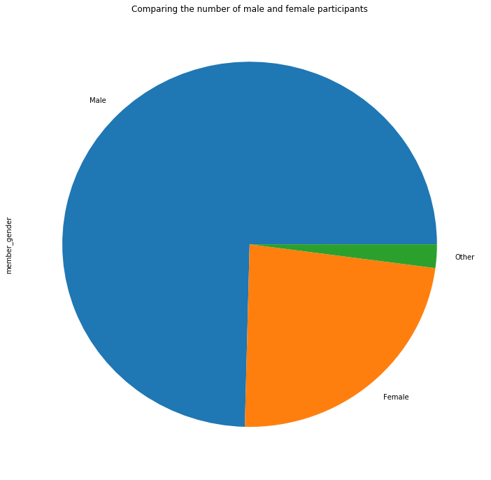

```python
#checking the gender of members that participated in the bike sharing
gender=gobike_trip.member_gender.value_counts()
print(gender)
gender.plot(kind='pie', title='Comparing the number of male and female participants', figsize=(12,12))
```

We have greater number of male 130500 members that registered and paticipated in the bike sharing system and less number of female of about 40805 members, about 3647 members witheld their gender identity. I thought of dropping the value others so as to focus on male and Female only but on the other hand I decided to keep it for record purpose, it has been discovered that once this section of data collection is made mandatory people tend to hide their gender.

#### How many users are subscribers and how many are customers?

```
Subscriber    158386
Customer       16566
Name: user_type, dtype: int64
```

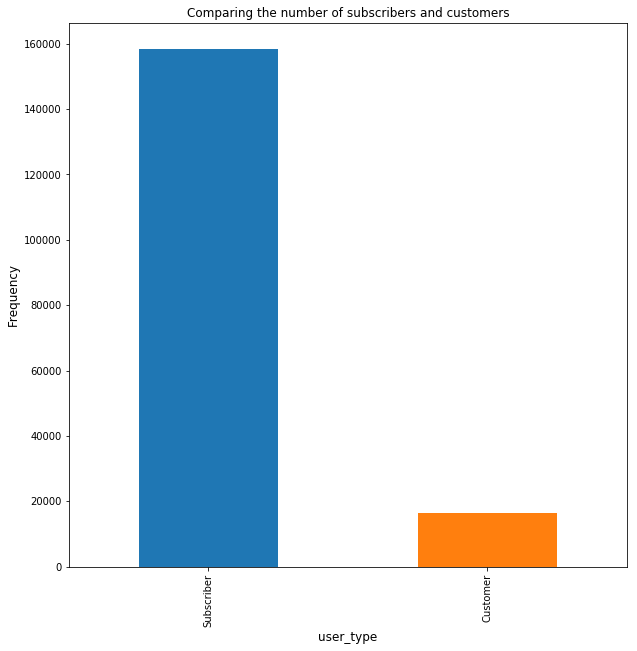

```python
#Comparing the number of subscribers and customers
usertype=gobike_trip.user_type.value_counts()
print(usertype)
plot_chart(usertype,'user_type','Frequency','Comparing the number of subscribers and customers','bar')
```

Here we have more subscribers than customer i.e we people that have purchased a slot for certain period of time than people that with one time purchase. We have over 150000 subscribers compared to the customers that are just 16566 people. I can also describe them as partners(subscribers) and clients(customers).

#### How many shared their bike in the bike sharing system?

```
No     157606
Yes     17346
Name: bike_share_for_all_trip, dtype: int64
```

```
[Text(0,0.5,'bike_id'),
 Text(0.5,0,'bike_share_for_all_trip'),
 Text(0.5,1,'Number of People that shared their bike for all trip')]
```

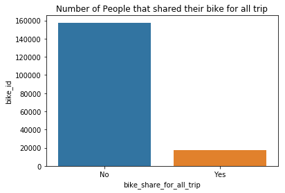

```python
# Number of perople that shared there bike for all the trip
print(gobike_trip.bike_share_for_all_trip.value_counts())
sb.countplot(data= gobike_trip, x = 'bike_share_for_all_trip').set(xlabel='bike_share_for_all_trip', ylabel='bike_id', title='Number of People that shared their bike for all trip')
```

We have just 17346 people that shared their bike during the trip compare with over 157000 people that did not share their bike during the trip.

#### What is the age range of the people using the bike share system?

```
Text(0,0.5,'Frequency')
```

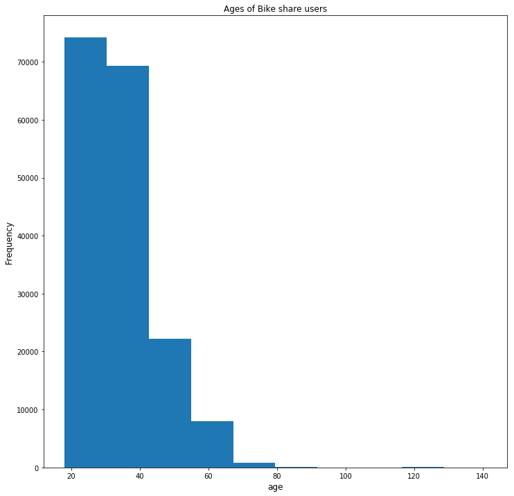

```python
#checking the age range of the people participating in the bike share system
gobike_trip.age.plot(kind ='hist', title='Ages of Bike share users', figsize=(12,12))
plt.xlabel('age', fontsize=12)
plt.ylabel('Frequency', fontsize=12)
```

```python
#converting the start_day column to category
from pandas.api.types import CategoricalDtype
cats = [ 'Monday', 'Tuesday', 'Wednesday', 'Thursday', 'Friday', 'Saturday', 'Sunday']
cat_type = CategoricalDtype(categories=cats, ordered=True)
gobike_trip['start_day']=gobike_trip['start_day'].astype(cat_type)

print(gobike_trip.start_day.unique())
gobike_trip.info()
```

[output not shown]

#### At what day of the week do we have the most trip taken?

```
Thursday     33712
Tuesday      30584
Wednesday    28426
Friday       27663
Monday       25641
Sunday       14512
Saturday     14414
Name: start_day, dtype: int64
```

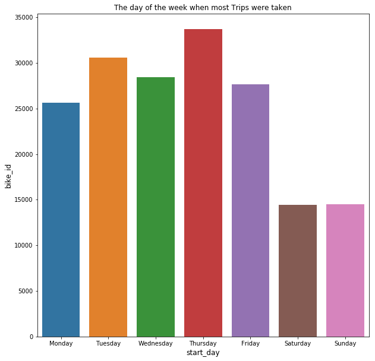

```python
#Checking the day of the week when most trips were taken
most_trip_day= gobike_trip.start_day.value_counts()
print(gobike_trip.start_day.value_counts())

bar_chart(gobike_trip,'start_day','bike_id',None,'The day of the week when most Trips were taken')
```

We discovered that most trips took place within the weekdays while less trips were taken on weekends especially on Saturday and Sunday. We recorded the most trip taken on Thursday followed by Tuesday, Wednesday, Friday, Monday, sunday and Saturday in that order.

#### At what time of the day are most Trips taken?

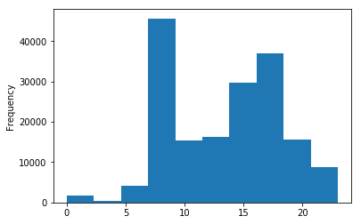

```python
#checking the time of the day at which most trips were carried out.
gobike_trip['start_hour'].plot(kind='hist')
```

Here we discovered that Most trips were taken in the morning between the hours of 7 and 10 AM and in the afternoon between 5 to 6PM.

### Discuss the distribution(s) of your variable(s) of interest. Were there any unusual points? Did you need to perform any transformations?

Lots of transformations were performed on this dataset so as to get the relevant information. More features were added for effective exploration such as start_month, end_month, start_day, end_day, Start_hour, end_hour, and age.

### Of the features you investigated, were there any unusual distributions? Did you perform any operations on the data to tidy, adjust, or change the form of the data? If so, why did you do this?

Some null values were discovered and cleaned for more accurate visualization. These null values were detected in the following features: start_station_id 197 start_station_name 197 end_station_id 197 end_station_name 197 member_birth_year 8265 member_gender 8265. I also discovered some erroneous datatype, these datatype were corrected so as to avoid wrong vasualization output.The corrections made is as follows: bike_share_for_all_trip initially has object dataype and was converted to category datatype; start_time initially has object dataype and was converted to Datetime datatype; and end_time initially has object dataype and was converted to datetime datetype

## Bivariate Exploration

```python
#creating some functions that will be used to plot our chart
def box_chart(df,x,y,h,t):
    plt.figure(figsize = [10, 10])
    sb.boxplot(data=df, x=x, y=y, hue=h).set(xlabel=x, ylabel=y, title=t)
    plt.xlabel(x, fontsize=12)
    plt.ylabel(y, fontsize=12)
    plt.title(t, fontsize=12)
    plt.legend()
    return plt.show();

def violin_chart(df,x,y,h,t):
    plt.figure(figsize = [10, 10])
    sb.violinplot(data=df, x=x, y=y, hue=h).set(xlabel=x, ylabel=y, title=t)
    plt.xlabel(x, fontsize=12)
    plt.ylabel(y, fontsize=12)
    plt.title(t, fontsize=12)
    plt.legend()
    return plt.show();

def bar_chart(df,x,h,t):
    plt.figure(figsize = [10, 10])
    sb.countplot(data = df, x = x, hue = h).set(xlabel=x, title=t)
    plt.xlabel(x, fontsize=12)
    plt.title(t, fontsize=12)
    plt.legend()
    return plt.show();

def scatter_chart(df,x,y,t):
    plt.figure(figsize = [10, 10])
    sb.regplot(data = df, x = x, y = y).set(xlabel=x, ylabel=y, title=t)
    plt.xlabel(x, fontsize=12)
    plt.ylabel(y, fontsize=12)
    plt.title(t, fontsize=12)
    plt.legend()
    return plt.show();

def stacked_chart(df,x,h,p,q,t):
    plt.figure(figsize = [10, 10])
    sb.countplot(data = df, x = x, hue = h, order = p, hue_order = q).set(xlabel=x, ylabel=y, title=t)
    plt.xlabel(x, fontsize=12)
    plt.ylabel(y, fontsize=12)
    plt.title(t, fontsize=12)
    plt.legend()
    return plt.show();
```

#### What is the total trip for the people that started from same location and ended same location?

```python
#creating same station round trip column
gobike_trip['same_station_round_trip']= np.where(gobike_trip['start_station_name'] == gobike_trip['end_station_name'], True, False)
```

```
same_station_round_trip
False    171494
True       3458
Name: duration_sec, dtype: int64
```

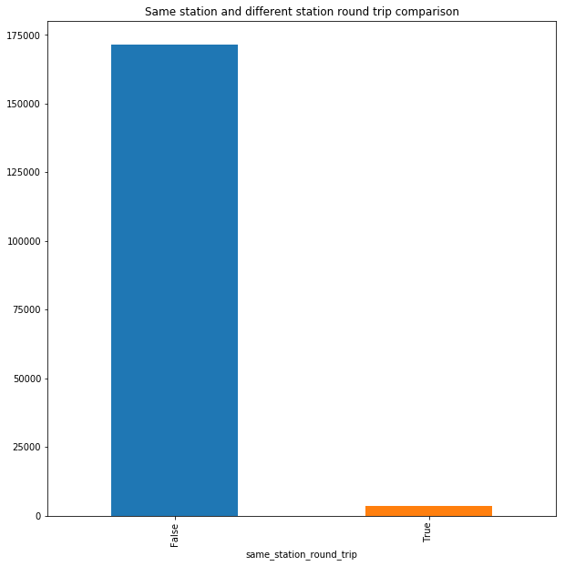

```python
#calculating the total trip made by people that stated and ended their trip on same station
same_station = gobike_trip.groupby(['same_station_round_trip']).count()['duration_sec']
print(same_station)
same_station.plot(kind='bar',title='Same station and different station round trip comparison',figsize = [10, 10])
```

We discovered that they were some trips that took off from a particular station and ended at the same station. We discovered that out of 174,952 trips taken, 3458 trips took off from same station and ended at same station while 171494 trips took off from a particular station and ended in another station.

#### What is the trip duration of the users from 80 years and above?

```python
aged = gobike_trip[gobike_trip['age']>=80]
print(aged['duration_sec'].count())
print(aged['age'].value_counts())
```

```
203
88     89
119    53
86     20
117    11
80     11
118     6
99      3
81      3
85      2
141     1
109     1
92      1
91      1
89      1
Name: age, dtype: int64
```

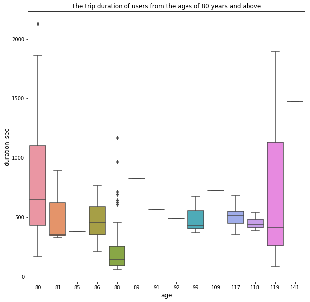

```python
box_chart(aged,'age','duration_sec',None,'The trip duration of users from the ages of 80 years and above')
```

We discoverd that about 203 aged people were registered for this trip. Their age range is as follows: age 88: 89 people, age 119:53 people, age 86:20 people, age 117:11 people, age 80:11 people, age 118:6 people,age 99:3 people,age 81:3 people,age 85: 2 people, age 141:1 person, aage 109: 1 person, age 92: 1 person, age 91:1 person,age 89: 1 person. Initially I wanted to clean up these records as anomaly but on the contrary, I considered that these people could be registered for this kindly for program purpose of exercise and to improve their health.

#### What is the total trip covered by subscriber users that shared their bike?

```
user_type   bike_share_for_all_trip
Customer    No                          16566
Subscriber  No                         141040
            Yes                         17346
Name: bike_share_for_all_trip, dtype: int64
```

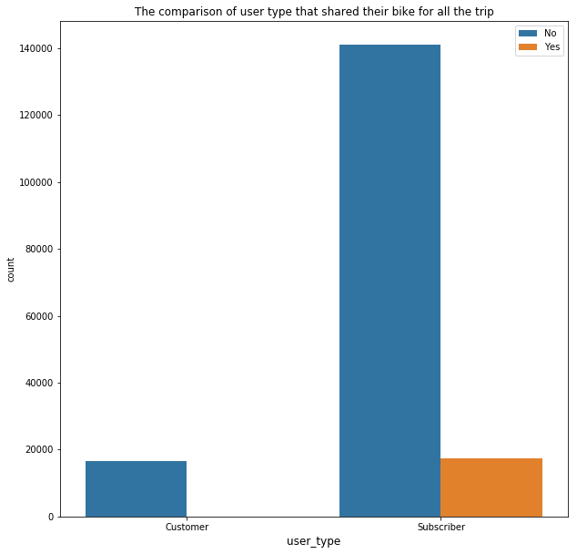

```python
#calculating the total trip made by scribers
usertype_bike_share=gobike_trip.groupby(['user_type'])
print(usertype_bike_share.bike_share_for_all_trip.value_counts())
bar_chart(gobike_trip,'user_type','bike_share_for_all_trip','The comparison of user type that shared their bike for all the trip')
```

We discovered that out of 158,386 Subscribers, only about 17346 people share their bike while the rest 141040 people did not share their bike. The customer did not share their Bikess at all though we have about 16566 customers that participated.

#### What day of the week has the peak duration covered?

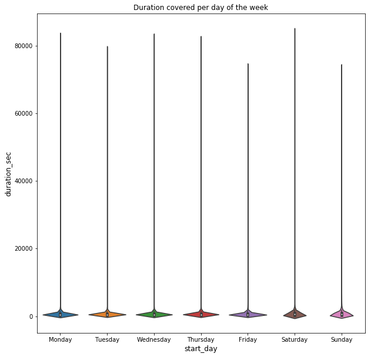

```python
#checking the total duration and total trip covered each day of the week.
violin_chart(gobike_trip,'start_day','duration_sec',None,'Duration covered per day of the week')
```

We can see from the chart that Saturday has the largest duration, followed Monday and then Wednesday.

#### At what time of the day do we have the highest trip?

```python
#creating start_session column to mark the trip covered either in the morning, afternoon, evening or night.
def f(x):
    if (x >= 5) and (x <= 12):
        return 'Morning'
    elif (x >12) and (x <= 17 ):
        return 'Afternoon'
    elif (x > 17) and (x <= 20):
        return'Evening'
    elif (x > 20):
        return 'Night'
    elif (x < 5):
        return 'Night'

gobike_trip['start_session']= gobike_trip['start_hour'].apply(f)
gobike_trip.start_session.unique()
```

```
array(['Afternoon', 'Morning', 'Night', 'Evening'], dtype=object)
```

```python
#updating the changes to the master dataset
gobike_trip.to_csv('201902-fordgobike-tripdata_master.csv', index=False)
```

```
Morning      73472
Afternoon    58798
Evening      31753
Night        10929
Name: start_session, dtype: int64
```

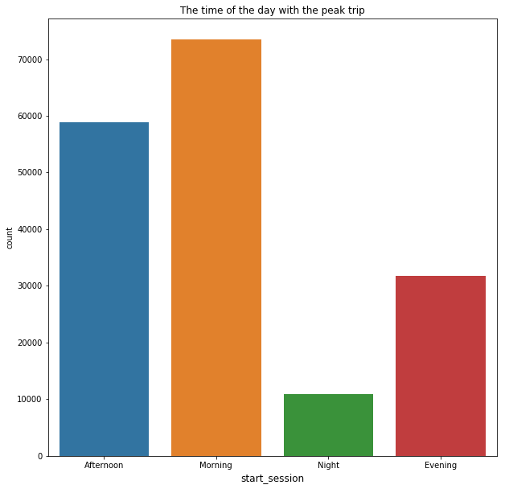

```python
#checking the time of the day when we have the peak trip
print(gobike_trip.start_session.value_counts())
bar_chart(gobike_trip,'start_session',None,'The time of the day with the peak trip')
```

We discoverd that most trips were taken in the morning like about 73472 trips, followed by afternoon and evening. Only few trips were taken in the Night like about 10929 trips

### Talk about some of the relationships you observed in this part of the investigation. How did the feature(s) of interest vary with other features in the dataset?

There us a great relationship between the user_type and bike share. The chart shows that only the subscribers user type were able to share their bike while the customer user type did not share their bike at all.

The relation between the Duration and start_hour/start_session shows that most trip were taken the morning hours during which much durations were accumulated.

### Did you observe any interesting relationships between the other features (not the main feature(s) of interest)?

The relationship between the start_station_name and end_station_name shows that some people actually began their trip from a particular station and ended their feature at same station

## Multivariate Exploration

```
member_gender  user_type
Female         Customer       6583744
               Subscriber    25198159
Male           Customer      14407550
               Subscriber    73339978
Other          Customer        721035
               Subscriber     2916222
Name: duration_sec, dtype: int64
```

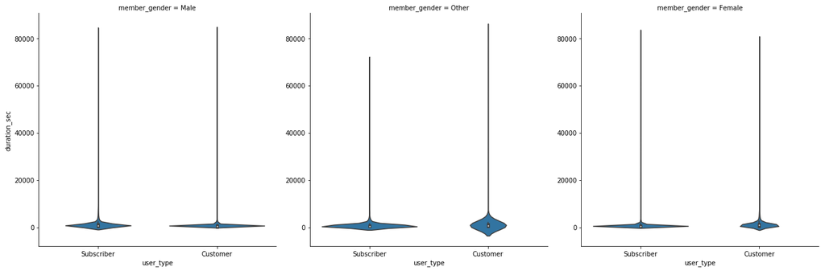

```python
#comparing the effect of member_gender and user_type on duration_sec
print(gobike_trip.groupby(['member_gender','user_type']).sum()['duration_sec'])
g = sb.FacetGrid(data = gobike_trip, col = 'member_gender', size = 6)
g.map(sb.violinplot, 'user_type', 'duration_sec')
```

There is positive relationship between the duration and user_type across members gender. The male subscribers and customers have the largest duration when compared to those of their female counterparts.

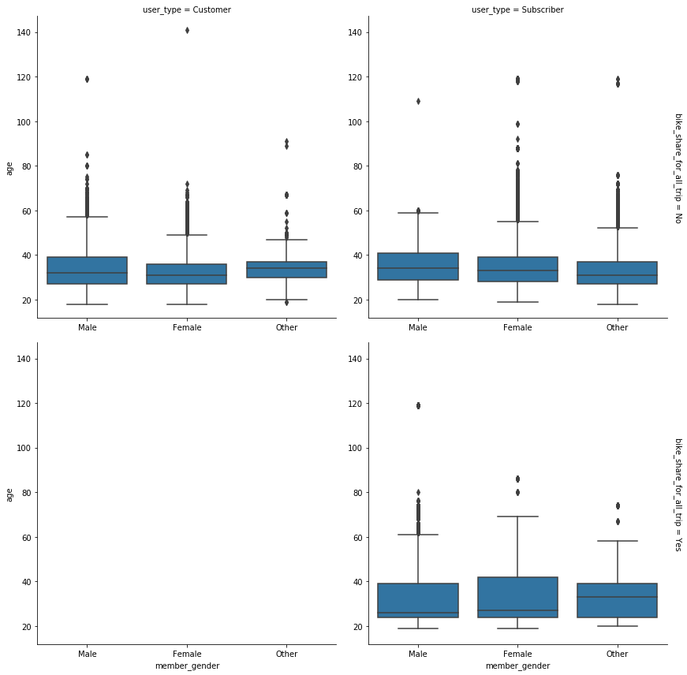

```python
#check the effect of these features to the trip: usertype, bike share, gender and age
g = sb.FacetGrid(data = gobike_trip, col = 'user_type', row = 'bike_share_for_all_trip', size = 6,
                margin_titles = True)
g.map(sb.boxplot, 'member_gender', 'age')
```

The relationship above shows that the female has more aged people and has lesser number people that shared their bike in all the trip when compared with that of male counterparts.

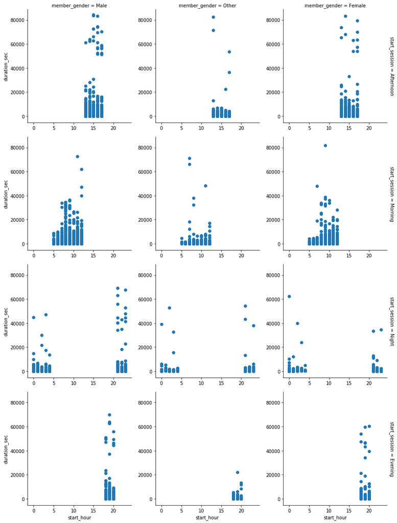

```python
#investigating effects of these feature on the duration time of the day, start session, gender, ages, duration

g = sb.FacetGrid(data = gobike_trip, col = 'member_gender', row = 'start_session', size = 4,
                margin_titles = True)
g.map(plt.scatter, 'start_hour', 'duration_sec')
```

There is a positive relationship between the duration_sec and start_hour across members gender in all the sessions of the day. The male took lead in the duration covered in all the day session (morning, afternoon, evening and night).

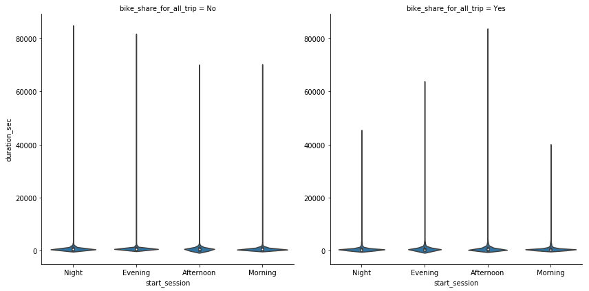

```python
#checking the effect of bike_share_for_all_trip and start_session om duration_sec
a = sb.FacetGrid(data = gobike_trip, col = 'bike_share_for_all_trip', size = 6)
a.map(sb.violinplot, 'start_session', 'duration_sec')
```

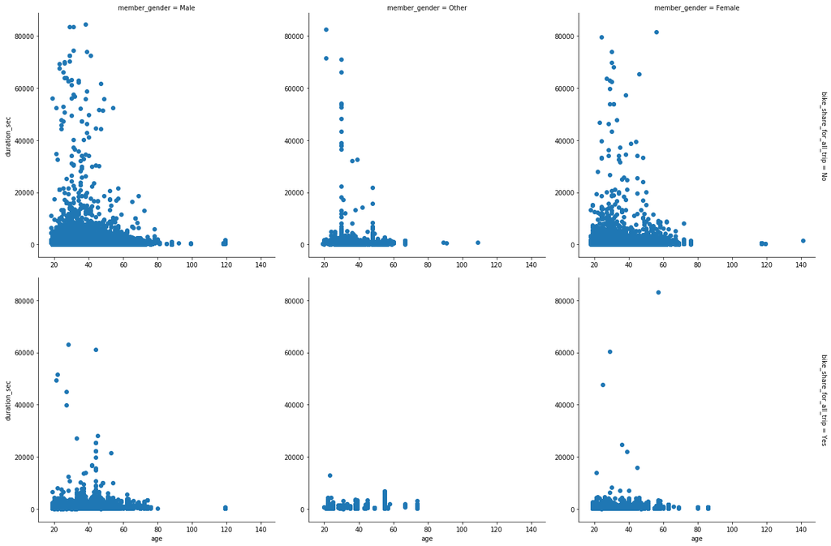

```python
#The effect of member_gender, bike_share_for_all_tripps and age on duration_sec
v = sb.FacetGrid(data = gobike_trip, col = 'member_gender', row = 'bike_share_for_all_trip', size = 6,
                margin_titles = True)
v.map(plt.scatter, 'age', 'duration_sec')
```

There is a negative relationship between the duration_sec and the age among the member gender that shared their bike and the once that did not share their trip as the age increases from 18 to 140 years.

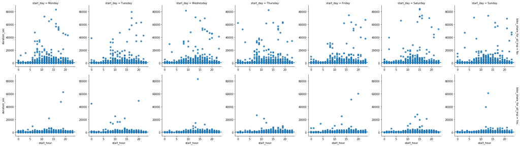

```python
# The effect of start_day, bike_share_for_all_trip and start_hour on duration_sec
h = sb.FacetGrid(data = gobike_trip, col = 'start_day', row = 'bike_share_for_all_trip', size = 4,
                margin_titles = True)
h.map(sb.regplot, 'start_hour', 'duration_sec')
```

There is positive relationship between the start_hour across the days of the week and among the people that shared their bike and the people that did not.

### Talk about some of the relationships you observed in this part of the investigation. Were there features that strengthened each other in terms of looking at your feature(s) of interest?

I investigated the the effect of other features such as user_type, member_gender,start_hour and start_session across bike_share_for_all_trip, reults shows positive relationship except in start_session for people that did not share their bike.

### Were there any interesting or surprising interactions between features?

The interesting interaction is the plot between duration_sec and age across gender and bike share that turn out negative as the age increases from left to right.

## Conclusions

A thorough investigations were carried out and we were able to get some insight into the dataset. We have more number of Bike riders than female. We have more number of subscribers than customer. we have more of the young adult population participating in the bike ride. More trips were taken on a weekday than weekend with Thursday having the largest number of trips recorded. Most Trips took place in the morning between the hours of 7-10 AM and in the afternoon. Some trips started from aparticular station and ended on same station. We discovered that there were aged people participating in the bike ride whose ages were above 80 years. We observed that only subscribers have their bike shared while customers did not share their bike at all. Male subscribers and customers has more duration when compared with those of their female counterparts. We have less female participants that shared their by bike but more aged people when compared with those of their male counterparts.